# Problem Set 1

`tidymodels` example

## 1 Setup

First, let’s load the packages and data…

```r
# Load necessary packages
library(pacman)
p_load(here, readr, skimr, fst, tidymodels, glmnet)
# Load the data
raw_df =
  here('projects', 'project-000', 'sales-data.fst') |>
  read_fst(as.data.table = TRUE)
  # read_fst(as.data.table = TRUE, from = 1, to = 2e4)
  # read_fst(as.data.table = TRUE) |> sample_frac(0.05)
```

## 2 Data cleaning and preprocessing

```r
# Recode variables
clean_df =
  raw_df |>
  # Parse characters to numbers
  mutate(
    sale_price = sale_price |> parse_number(),
    land_square_feet = land_square_feet |> parse_number(),
    building_square_feet = building_square_feet |> parse_number(),
    number_of_units = number_of_units |> parse_number(),
    percent_ownership = percent_ownership |> parse_number(),
    other_improvements = other_improvements |> parse_number(),
  ) |>
  # Convert numeric variables to factors
  mutate(
    across(
      c(
        ends_with('material'),
        ends_with('finish'),
        contains('class'),
        pin, use, type_of_residence, design_plan, multi_code
      ),
    as.character
    )
  ) |>
  # Remove unwanted variables :(
  select(!starts_with('square_root')) |>
  select(!contains('squared')) |>
  select(!starts_with('estimate')) |>
  select(!c(
    deed_no, census_tract,
    town_code, town_and_neighborhood,
    neighborhood_code, neigborhood_code_mapping,
    total_building_square_feet, property_address,
    sale_date, pure_market_filter
  ))
```

I’m also going to remove observations with a sales price less than or equal to $1. Ideally, we would have a flag for “non-arm’s-length” sales. We don’t, so this crude filter is the best we can do to remove non-arm’s-length sales.

```r
# Filter out non-arm's-length sales
clean_df = clean_df |> filter(sale_price > 1)

# Check it out
clean_df |> skim()
```

Data summary

| Name | clean_df |
| --- | --- |
| Number of rows | 333615 |
| Number of columns | 64 |
| Key | NULL |
| _______________________ |  |
| Column type frequency: |  |
| character | 15 |
| logical | 1 |
| numeric | 48 |
| ________________________ |  |
| Group variables | None |

**Variable type: character**

| skim_variable | n_missing | complete_rate | min | max | empty | n_unique | whitespace |
| --- | --- | --- | --- | --- | --- | --- | --- |
| pin | 0 | 1 | 14 | 21 | 0 | 267980 | 0 |
| property_class | 0 | 1 | 3 | 3 | 0 | 14 | 0 |
| type_of_residence | 0 | 1 | 1 | 1 | 0 | 8 | 0 |
| wall_material | 0 | 1 | 1 | 1 | 0 | 4 | 0 |
| roof_material | 0 | 1 | 1 | 1 | 0 | 6 | 0 |
| basement_finish | 1 | 1 | 1 | 1 | 0 | 3 | 0 |
| attic_finish | 0 | 1 | 1 | 1 | 0 | 4 | 0 |
| design_plan | 0 | 1 | 1 | 1 | 0 | 3 | 0 |
| garage_1_material | 0 | 1 | 1 | 1 | 0 | 5 | 0 |
| garage_2_material | 0 | 1 | 1 | 1 | 0 | 4 | 0 |
| multi_code | 0 | 1 | 1 | 2 | 0 | 27 | 0 |
| modeling_group | 0 | 1 | 2 | 2 | 0 | 2 | 0 |
| use | 0 | 1 | 1 | 1 | 0 | 2 | 0 |
| condo_class_factor | 333615 | 0 | NA | NA | 0 | 0 | 0 |
| condition_desirability_and_utility | 0 | 1 | 0 | 2 | 314723 | 17 | 0 |

**Variable type: logical**

| skim_variable | n_missing | complete_rate | mean | count |
| --- | --- | --- | --- | --- |
| large_lot | 333615 | 0 | NaN | : |

**Variable type: numeric**

| skim_variable | n_missing | complete_rate | mean | sd | p0 | p25 | p50 | p75 | p100 | hist |
| --- | --- | --- | --- | --- | --- | --- | --- | --- | --- | --- |
| land_square_feet | 0 | 1.00 | 7018.69 | 13323.39 | 149.00 | 3720.00 | 5060.00 | 7980.00 | 2980767.00 | ▇▁▁▁▁ |
| apartments | 0 | 1.00 | 0.39 | 1.05 | -5.00 | 0.00 | 0.00 | 0.00 | 6.00 | ▁▁▇▁▁ |
| rooms | 0 | 1.00 | 7.08 | 3.35 | 2.00 | 5.00 | 6.00 | 8.00 | 241.00 | ▇▁▁▁▁ |
| bedrooms | 0 | 1.00 | 3.54 | 1.53 | 1.00 | 3.00 | 3.00 | 4.00 | 90.00 | ▇▁▁▁▁ |
| basement | 0 | 1.00 | 1.72 | 0.97 | 1.00 | 1.00 | 1.00 | 3.00 | 4.00 | ▇▂▁▃▁ |
| central_heating | 0 | 1.00 | 1.16 | 0.37 | 0.00 | 1.00 | 1.00 | 1.00 | 2.00 | ▁▁▇▁▂ |
| other_heating | 0 | 1.00 | 4.89 | 0.56 | 2.00 | 5.00 | 5.00 | 5.00 | 5.00 | ▁▁▁▁▇ |
| central_air | 0 | 1.00 | 0.47 | 0.50 | 0.00 | 0.00 | 0.00 | 1.00 | 1.00 | ▇▁▁▁▇ |
| fireplaces | 0 | 1.00 | 0.31 | 0.54 | 0.00 | 0.00 | 0.00 | 1.00 | 2.00 | ▇▁▂▁▁ |
| attic_type | 0 | 1.00 | 2.49 | 0.79 | 1.00 | 2.00 | 3.00 | 3.00 | 3.00 | ▂▁▂▁▇ |
| half_baths | 0 | 1.00 | 0.46 | 0.57 | 0.00 | 0.00 | 0.00 | 1.00 | 9.00 | ▇▁▁▁▁ |
| cathedral_ceiling | 0 | 1.00 | 0.88 | 0.97 | 0.00 | 0.00 | 0.00 | 2.00 | 2.00 | ▇▁▁▁▆ |
| construction_quality | 0 | 1.00 | 1.99 | 0.11 | 1.00 | 2.00 | 2.00 | 2.00 | 3.00 | ▁▁▇▁▁ |
| renovation | 333006 | 0.00 | 1.12 | 0.33 | 1.00 | 1.00 | 1.00 | 1.00 | 2.00 | ▇▁▁▁▁ |
| site_desirability | 0 | 1.00 | 2.00 | 0.08 | 1.00 | 2.00 | 2.00 | 2.00 | 3.00 | ▁▁▇▁▁ |
| garage_1_size | 0 | 1.00 | 2.27 | 1.36 | 0.00 | 1.00 | 3.00 | 3.00 | 7.00 | ▅▁▇▁▁ |
| garage_1_attachment | 0 | 1.00 | 1.37 | 0.75 | 0.00 | 1.00 | 2.00 | 2.00 | 2.00 | ▂▁▅▁▇ |
| garage_1_area | 0 | 1.00 | 1.58 | 0.76 | 0.00 | 1.00 | 2.00 | 2.00 | 2.00 | ▂▁▁▁▇ |
| garage_2_size | 0 | 1.00 | 7.00 | 0.11 | 1.00 | 7.00 | 7.00 | 7.00 | 7.00 | ▁▁▁▁▇ |
| garage_2_attachment | 0 | 1.00 | 0.00 | 0.04 | 0.00 | 0.00 | 0.00 | 0.00 | 2.00 | ▇▁▁▁▁ |
| garage_2_area | 0 | 1.00 | 0.01 | 0.15 | 0.00 | 0.00 | 0.00 | 0.00 | 4.00 | ▇▁▁▁▁ |
| porch | 0 | 1.00 | 2.66 | 0.75 | 1.00 | 3.00 | 3.00 | 3.00 | 3.00 | ▂▁▁▁▇ |
| other_improvements | 0 | 1.00 | 15.27 | 517.79 | 0.00 | 0.00 | 0.00 | 0.00 | 84336.00 | ▇▁▁▁▁ |
| building_square_feet | 0 | 1.00 | 1806.23 | 1046.84 | 392.00 | 1128.00 | 1473.00 | 2174.00 | 21796.00 | ▇▁▁▁▁ |
| repair_condition | 0 | 1.00 | 2.00 | 0.12 | 1.00 | 2.00 | 2.00 | 2.00 | 3.00 | ▁▁▇▁▁ |
| number_of_commercial_units | 0 | 1.00 | 0.01 | 0.12 | 0.00 | 0.00 | 0.00 | 0.00 | 5.00 | ▇▁▁▁▁ |
| sale_price | 0 | 1.00 | 288388.40 | 343122.18 | 2.00 | 119000.00 | 214100.00 | 349000.00 | 71000000.00 | ▇▁▁▁▁ |
| longitude | 3424 | 0.99 | -87.78 | 0.15 | -88.26 | -87.84 | -87.75 | -87.68 | -87.52 | ▁▁▃▇▃ |
| latitude | 3424 | 0.99 | 41.85 | 0.17 | 41.47 | 41.73 | 41.87 | 42.00 | 42.15 | ▃▅▇▇▆ |
| multi_property_indicator | 0 | 1.00 | 0.02 | 0.14 | 0.00 | 0.00 | 0.00 | 0.00 | 1.00 | ▇▁▁▁▁ |
| full_baths | 0 | 1.00 | 1.69 | 0.92 | 1.00 | 1.00 | 1.00 | 2.00 | 42.00 | ▇▁▁▁▁ |
| age | 0 | 1.00 | 65.80 | 32.20 | 1.00 | 46.00 | 61.00 | 91.00 | 181.00 | ▃▇▅▂▁ |
| number_of_units | 333615 | 0.00 | NaN | NA | NA | NA | NA | NA | NA |  |
| percent_ownership | 332778 | 0.00 | 52.91 | 16.12 | 10.00 | 50.00 | 50.00 | 50.00 | 98.00 | ▁▁▇▂▁ |
| multi_family_indicator | 282226 | 0.15 | 211.06 | 0.24 | 211.00 | 211.00 | 211.00 | 211.00 | 212.00 | ▇▁▁▁▁ |
| o_hare_noise | 3424 | 0.99 | 0.01 | 0.12 | 0.00 | 0.00 | 0.00 | 0.00 | 1.00 | ▇▁▁▁▁ |
| floodplain | 3424 | 0.99 | 0.02 | 0.15 | 0.00 | 0.00 | 0.00 | 0.00 | 1.00 | ▇▁▁▁▁ |
| road_proximity | 3424 | 0.99 | 0.08 | 0.27 | 0.00 | 0.00 | 0.00 | 0.00 | 1.00 | ▇▁▁▁▁ |
| condo_strata | 333615 | 0.00 | NaN | NA | NA | NA | NA | NA | NA |  |
| sale_year | 0 | 1.00 | 2016.06 | 2.00 | 2013.00 | 2014.00 | 2016.00 | 2018.00 | 2019.00 | ▇▃▅▅▇ |
| sale_quarter | 0 | 1.00 | 78.80 | 7.99 | 65.00 | 72.00 | 79.00 | 86.00 | 92.00 | ▇▆▇▇▇ |
| sale_half_year | 0 | 1.00 | 39.65 | 3.99 | 33.00 | 36.00 | 40.00 | 43.00 | 46.00 | ▇▆▅▇▇ |
| sale_quarter_of_year | 0 | 1.00 | 2.56 | 1.07 | 1.00 | 2.00 | 3.00 | 3.00 | 4.00 | ▆▇▁▇▆ |
| sale_month_of_year | 0 | 1.00 | 6.65 | 3.27 | 1.00 | 4.00 | 7.00 | 9.00 | 12.00 | ▇▆▆▆▇ |
| sale_half_of_year | 0 | 1.00 | 1.53 | 0.50 | 1.00 | 1.00 | 2.00 | 2.00 | 2.00 | ▇▁▁▁▇ |
| most_recent_sale | 214 | 1.00 | 0.76 | 0.43 | 0.00 | 1.00 | 1.00 | 1.00 | 1.00 | ▂▁▁▁▇ |
| age_decade | 0 | 1.00 | 6.58 | 3.22 | 0.10 | 4.60 | 6.10 | 9.10 | 18.10 | ▃▇▅▂▁ |
| garage_indicator | 0 | 1.00 | 0.83 | 0.37 | 0.00 | 1.00 | 1.00 | 1.00 | 1.00 | ▂▁▁▁▇ |

Let’s define a recipe for cleaning and preprocessing the data. As discussed in class, we’ll *at least* need to convert categorical predictors to dummies and standardize the numeric predictors.

```r
# Define a recipe for preprocessing the data
a_recipe =
  # Start the recipe
  recipe(sale_price ~ ., data = clean_df) |>
  # Update ID variable role
  update_role(pin, new_role = "id") |>
  # Drop variables with too many missing values
  step_filter_missing(all_predictors(), threshold = 0.01) |>
  # Impute missing values in numeric predictors with the median
  step_impute_median(all_numeric_predictors()) |>
  # Interact numeric predictors with each other
  step_interact(~ all_numeric_predictors():all_numeric_predictors()) |>
  # Normalize numeric predictors
  step_normalize(all_numeric_predictors()) |>
  # Impute missing values in categorical predictors with the most common value
  step_impute_mode(all_nominal_predictors()) |>
  # Collapse infrequent factor levels into 'other'
  step_other(all_nominal_predictors(), threshold = 0.05) |>
  # Create dummy variables for categorical predictors
  step_dummy(all_nominal_predictors(), one_hot = TRUE) |>
  # Remove near-zero-variance predictors
  step_nzv(all_predictors()) |>
  # Remove predictors that are highly correlated with other predictors
  step_corr(all_predictors(), threshold = 0.9) |>
  # Remove variables that are linear combinations of other predictors
  step_lincomb(all_predictors())

# Let's see the recipe
a_recipe
```

```
── Recipe ──────────────────────────────────────────────────────────────────────
```

```
── Inputs
```

```
Number of variables by role
```

```
outcome:    1
predictor: 62
id:         1
```

```
── Operations
```

```
• Missing value column filter on: all_predictors()
```

```
• Median imputation for: all_numeric_predictors()
```

```
• Interactions with: all_numeric_predictors():all_numeric_predictors()
```

```
• Centering and scaling for: all_numeric_predictors()
```

```
• Mode imputation for: all_nominal_predictors()
```

```
• Collapsing factor levels for: all_nominal_predictors()
```

```
• Dummy variables from: all_nominal_predictors()
```

```
• Sparse, unbalanced variable filter on: all_predictors()
```

```
• Correlation filter on: all_predictors()
```

```
• Linear combination filter on: all_predictors()
```

Notice that executing this recipe *once* takes quite some time.

```r
# Time the execution of the recipe
tictoc::tic()
baked_df = a_recipe |> prep() |> bake(new_data = NULL)
tictoc::toc()
```

```
198.264 sec elapsed
```

```r
# Check out the baked data
baked_df |> skim()
```

Data summary

| Name | baked_df |
| --- | --- |
| Number of rows | 333615 |
| Number of columns | 156 |
| _______________________ |  |
| Column type frequency: |  |
| character | 1 |
| numeric | 155 |
| ________________________ |  |
| Group variables | None |

**Variable type: character**

| skim_variable | n_missing | complete_rate | min | max | empty | n_unique | whitespace |
| --- | --- | --- | --- | --- | --- | --- | --- |
| pin | 0 | 1 | 14 | 21 | 0 | 267980 | 0 |

**Variable type: numeric**

| skim_variable | n_missing | complete_rate | mean | sd | p0 | p25 | p50 | p75 | p100 | hist |
| --- | --- | --- | --- | --- | --- | --- | --- | --- | --- | --- |
| sale_year | 0 | 1 | 0.00 | 1.00 | -1.53 | -1.03 | -0.03 | 0.97 | 1.4700e+00 | ▇▃▅▅▇ |
| sale_price | 0 | 1 | 288388.40 | 343122.18 | 2.00 | 119000.00 | 214100.00 | 349000.00 | 7.1000e+07 | ▇▁▁▁▁ |
| land_square_feet_x_basement | 0 | 1 | 0.00 | 1.00 | -0.41 | -0.30 | -0.21 | 0.10 | 2.6801e+02 | ▇▁▁▁▁ |
| land_square_feet_x_central_heating | 0 | 1 | 0.00 | 1.00 | -0.46 | -0.24 | -0.10 | 0.05 | 3.4300e+02 | ▇▁▁▁▁ |
| land_square_feet_x_garage_1_size | 0 | 1 | 0.00 | 1.00 | -0.35 | -0.26 | -0.14 | 0.06 | 2.3421e+02 | ▇▁▁▁▁ |
| land_square_feet_x_garage_1_attachment | 0 | 1 | 0.00 | 1.00 | -0.46 | -0.17 | -0.07 | 0.10 | 2.9191e+02 | ▇▁▁▁▁ |
| land_square_feet_x_building_square_feet | 0 | 1 | 0.00 | 1.00 | -0.26 | -0.17 | -0.12 | -0.02 | 3.0528e+02 | ▇▁▁▁▁ |
| land_square_feet_x_most_recent_sale | 0 | 1 | 0.00 | 1.00 | -0.44 | -0.36 | -0.12 | 0.14 | 2.3849e+02 | ▇▁▁▁▁ |
| land_square_feet_x_age_decade | 0 | 1 | 0.00 | 1.00 | -0.37 | -0.15 | -0.05 | 0.04 | 3.4956e+02 | ▇▁▁▁▁ |
| apartments_x_basement | 0 | 1 | 0.00 | 1.00 | -8.84 | -0.32 | -0.32 | -0.32 | 1.3320e+01 | ▁▇▁▁▁ |
| apartments_x_central_heating | 0 | 1 | 0.00 | 1.00 | -6.38 | -0.34 | -0.34 | -0.34 | 6.9000e+00 | ▁▁▇▁▁ |
| apartments_x_cathedral_ceiling | 0 | 1 | 0.00 | 1.00 | -6.18 | -0.30 | -0.30 | -0.30 | 6.7600e+00 | ▁▁▇▁▁ |
| apartments_x_porch | 0 | 1 | 0.00 | 1.00 | -5.69 | -0.34 | -0.34 | -0.34 | 6.0900e+00 | ▁▁▇▁▁ |
| apartments_x_full_baths | 0 | 1 | 0.00 | 1.00 | -8.08 | -0.28 | -0.28 | -0.28 | 1.5760e+01 | ▁▇▁▁▁ |
| apartments_x_sale_half_of_year | 0 | 1 | 0.00 | 1.00 | -6.28 | -0.35 | -0.35 | -0.35 | 6.7600e+00 | ▁▁▇▁▁ |
| apartments_x_most_recent_sale | 0 | 1 | 0.00 | 1.00 | -5.82 | -0.31 | -0.31 | -0.31 | 6.3100e+00 | ▁▁▇▁▁ |
| apartments_x_garage_indicator | 0 | 1 | 0.00 | 1.00 | -6.71 | -0.30 | -0.30 | -0.30 | 7.4000e+00 | ▁▁▇▁▁ |
| rooms_x_bedrooms | 0 | 1 | 0.00 | 1.00 | -0.55 | -0.29 | -0.23 | 0.05 | 3.2051e+02 | ▇▁▁▁▁ |
| rooms_x_full_baths | 0 | 1 | 0.00 | 1.00 | -0.62 | -0.47 | -0.32 | 0.09 | 7.1930e+01 | ▇▁▁▁▁ |
| bedrooms_x_basement | 0 | 1 | 0.00 | 1.00 | -1.26 | -0.75 | -0.49 | 0.79 | 2.1500e+01 | ▇▁▁▁▁ |
| bedrooms_x_central_heating | 0 | 1 | 0.00 | 1.00 | -1.40 | -0.41 | -0.41 | -0.08 | 5.8020e+01 | ▇▁▁▁▁ |
| bedrooms_x_other_heating | 0 | 1 | 0.00 | 1.00 | -1.97 | -0.30 | -0.30 | 0.35 | 5.5590e+01 | ▇▁▁▁▁ |
| bedrooms_x_attic_type | 0 | 1 | 0.00 | 1.00 | -1.51 | -0.55 | 0.02 | 0.60 | 5.0160e+01 | ▇▁▁▁▁ |
| bedrooms_x_half_baths | 0 | 1 | 0.00 | 1.00 | -0.56 | -0.56 | -0.56 | 0.44 | 5.8320e+01 | ▇▁▁▁▁ |
| bedrooms_x_cathedral_ceiling | 0 | 1 | 0.00 | 1.00 | -0.78 | -0.78 | -0.78 | 0.64 | 1.0570e+01 | ▇▁▁▁▁ |
| bedrooms_x_garage_1_size | 0 | 1 | 0.00 | 1.00 | -1.16 | -0.73 | 0.13 | 0.56 | 3.7580e+01 | ▇▁▁▁▁ |
| bedrooms_x_garage_1_area | 0 | 1 | 0.00 | 1.00 | -1.56 | -0.42 | 0.16 | 0.73 | 5.0110e+01 | ▇▁▁▁▁ |
| bedrooms_x_porch | 0 | 1 | 0.00 | 1.00 | -1.71 | -0.68 | -0.07 | 0.55 | 5.3620e+01 | ▇▁▁▁▁ |
| bedrooms_x_age | 0 | 1 | 0.00 | 1.00 | -1.24 | -0.57 | -0.29 | 0.26 | 4.3410e+01 | ▇▁▁▁▁ |
| bedrooms_x_sale_month_of_year | 0 | 1 | 0.00 | 1.00 | -1.39 | -0.71 | -0.16 | 0.52 | 4.3040e+01 | ▇▁▁▁▁ |

[output cut: 125 more lines]

So if you are then asking R to run this recipe *each* time you fit a model (for each fold of cross-validation, for each value of the tuning parameters), that can add up to *a lot* of time.

One more note: I used `step_other` to collapse infrequent factor levels to an “other” category. This step will help you avoid creating a huge number of dummy variables that are mostly `0`s. However, it *could* cause you to lose important information.

## 3 Elasticnet

Now we can set up our **workflow**. We will need to specify and model. Then we can add our recipe.

```r
# Define the model specification
net_model =
  linear_reg(penalty = tune(), mixture = tune()) |>
  set_engine('glmnet')
# Define the workflow
net_wf =
  workflow() |>
  add_model(net_model) |>
  add_recipe(a_recipe)

# Print the workflow
net_wf
```

```
══ Workflow ════════════════════════════════════════════════════════════════════
Preprocessor: Recipe
Model: linear_reg()

── Preprocessor ────────────────────────────────────────────────────────────────
10 Recipe Steps

• step_filter_missing()
• step_impute_median()
• step_interact()
• step_normalize()
• step_impute_mode()
• step_other()
• step_dummy()
• step_nzv()
• step_corr()
• step_lincomb()

── Model ───────────────────────────────────────────────────────────────────────
Linear Regression Model Specification (regression)

Main Arguments:
  penalty = tune()
  mixture = tune()

Computational engine: glmnet
```

We’re finally ready to tune the model… after we create a resampling object (define the folds) and define the set of tuning parameters we wish to evaluate.

This may take some time. I’m going to use `tictoc` to time the execution of this code chunk again.

Note that parallelization can help here—to a degree. Tuning 5 levels of `lambda` took 99 seconds to run sequentially on my computer. When I parallelized (with 5 workers in `future`), the same code took approxiately 30 seconds.

```r
# Start timer
tictoc::tic()

# Define the resampling object
set.seed(12)
cv_folds = vfold_cv(clean_df, v = 5)
# Parallelize the tuning process
library(future)
plan(multisession, workers = parallelly::availableCores() - 1)
# Tune the model
tune_results =
  tune_grid(
    net_wf,
    resamples = cv_folds,
    grid = expand_grid(
      penalty = 10^seq(-5, 3, length.out = 50),
      mixture = seq(0, 1, length.out = 11)
    ),
    metrics = metric_set(rmse, mae, rsq),
    control = control_grid(parallel_over = 'everything')
  )
```

[output not shown]

[output not shown]

[output not shown]

[output not shown]

[output cut: 22 more lines]

[output not shown]

[output not shown]

```r
# Stop timer
tictoc::toc()
```

```
2462.463 sec elapsed
```

```r
# Check out the tuning results: RMSE
tune_results |> show_best(metric = 'rmse', n = 10)
```

```
# A tibble: 10 × 8
     penalty mixture .metric .estimator    mean     n std_err .config
       <dbl>   <dbl> <chr>   <chr>        <dbl> <int>   <dbl> <chr>
 1 0.00001       0.3 rmse    standard   261620.     5  23943. Preprocessor1_Mod…
 2 0.0000146     0.3 rmse    standard   261620.     5  23943. Preprocessor1_Mod…
 3 0.0000212     0.3 rmse    standard   261620.     5  23943. Preprocessor1_Mod…
 4 0.0000309     0.3 rmse    standard   261620.     5  23943. Preprocessor1_Mod…
 5 0.0000450     0.3 rmse    standard   261620.     5  23943. Preprocessor1_Mod…
 6 0.0000655     0.3 rmse    standard   261620.     5  23943. Preprocessor1_Mod…
 7 0.0000954     0.3 rmse    standard   261620.     5  23943. Preprocessor1_Mod…
 8 0.000139      0.3 rmse    standard   261620.     5  23943. Preprocessor1_Mod…
 9 0.000202      0.3 rmse    standard   261620.     5  23943. Preprocessor1_Mod…
10 0.000295      0.3 rmse    standard   261620.     5  23943. Preprocessor1_Mod…
```

```r
# Check out the tuning results: MAE
tune_results |> show_best(metric = 'mae', n = 10)
```

```
# A tibble: 10 × 8
   penalty mixture .metric .estimator    mean     n std_err .config
     <dbl>   <dbl> <chr>   <chr>        <dbl> <int>   <dbl> <chr>
 1    687.     0.1 mae     standard   137617.     5    267. Preprocessor1_Model…
 2    471.     0.2 mae     standard   137618.     5    266. Preprocessor1_Model…
 3    324.     0.2 mae     standard   137623.     5    261. Preprocessor1_Model…
 4    471.     0.1 mae     standard   137625.     5    263. Preprocessor1_Model…
 5    324.     0.3 mae     standard   137625.     5    265. Preprocessor1_Model…
 6   1000      0.1 mae     standard   137626.     5    273. Preprocessor1_Model…
 7    222.     0.4 mae     standard   137627.     5    263. Preprocessor1_Model…
 8    222.     0.5 mae     standard   137628.     5    267. Preprocessor1_Model…
 9    324.     0.4 mae     standard   137631.     5    267. Preprocessor1_Model…
10    222.     0.3 mae     standard   137631.     5    261. Preprocessor1_Model…
```

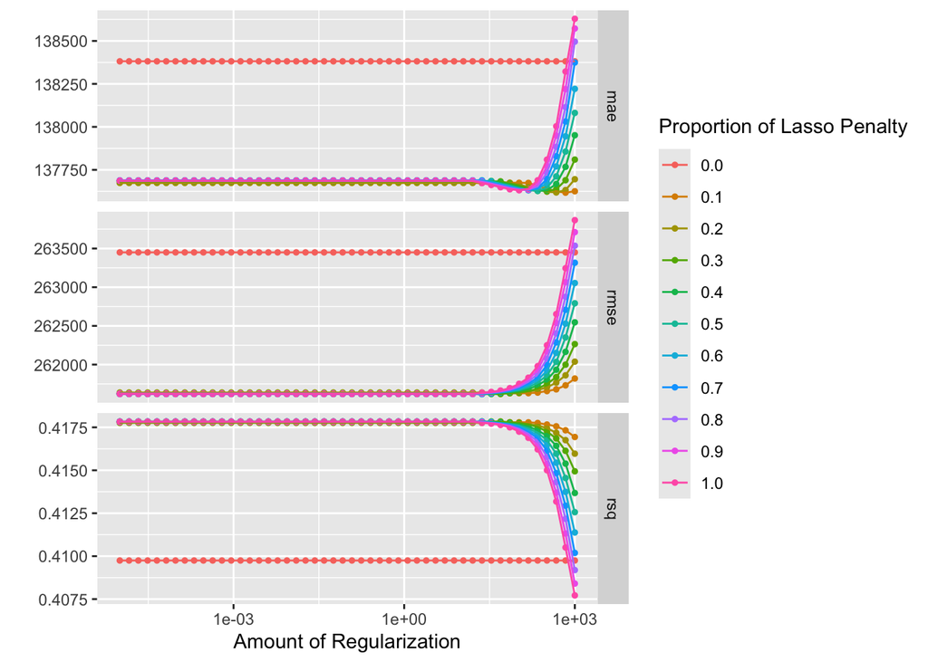

```r
# Plot the tuning results
tune_results |> autoplot()
```